# Creating images with R

with a little bit of magick

Huanyu Liu

```css
/* Change background color to light blue */
body {
    background-color: #D5F5E3;
}

/* Increase font size for all paragraphs */
p {
    font-size: 18px;
}

/* Add a border to all images */
img {
    border: 2px solid #999;
    border-radius: 8px;
}
```

## Project requirements

in order to meet the requirement, I check the demo you illustrate to us,first, the requirement ask for two head. from demo, I learnt that each header I just need to add “#” in front of sentences.Second for the two typeface. I searched from website how to write with different typeface, which used by adding “*“.for order part, I add”-’ in front of my sentences which sentences I want to be neat.At last, for the website link,I choose my the trailer for favorite movie(zootopia). In additional, I also paste my favorite picture of this movie. That all steps how I meet the requirement of Github. https://0925parker.github.io/stats220/ My project: https://0925parker.github.io/project1/

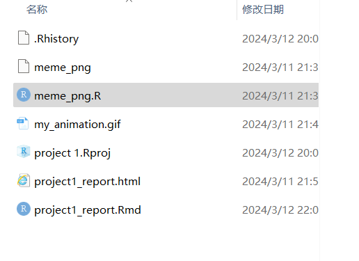

```r
screenshot <- image_read("E:/steam/STUDY/46dc04305e8a1e7294d3921dd71dcb9.png")
screenshot
```

## My meme

[figure not shown]

```r
meme1 <- image_read("https://pic.baike.soso.com/ugc/baikepic2/20444/cut-20180818231215-1211854547_jpg_629_419_24943.jpg/1284")
image_scale1 <- image_scale(meme1,400)
meme2 <- image_read("https://encrypted-tbn0.gstatic.com/images?q=tbn:ANd9GcQRorFf_WqmhN7yevPJXPMmZMEpibDSluYa2Q&usqp=CAU")

image_scale2 <- image_scale(meme2,400)

blank1 <- image_blank(width = 400,
            height = 400,
            color = "#953500") %>%
  image_annotate(text = "witchcraft",
                 color = "#999999",
                 size = 40,
                 font = "center")

blank2 <- image_blank(width = 400,
                      height = 400,
                      color = "#596628") %>%
  image_annotate(text = "Be afraid,human",
                 color = "#999999",
                 size = 40,
                 font = "center")

picture <- c(blank1,image_scale1,image_scale2,blank2)

final_image <-image_append(picture)

final_image
```

[figure not shown]

```r
animation <- image_animate(picture,fps = 1)

image_write(animation,"my_animation.gif")
```

## Creativity

I add the link of my favorite movie’s picture and made it visible directly in the laboratory, not in code form.

## Learning reflection

from module 1, I learnt a lot of knowledge I have ever heard about. The most significant idea I learnt is how to use pictures to make it flash and edit it on my commend or based on my idea.For the part which I interested most also is this part. In the past, my friend use my wired or ugly pictures to create a gif to let us laugh. at that time I am curious how did he do it.Now I can make it eye for eye and make some interesting picture or gif. That’s learning reflection on this module.